# Risk Factor Analysis

## Outcome Variable

**Outcome Variable:** co_occurence

## Predictor Variables

**Intervention Variable:** ever_sstunted06

**Adjustment Set:**

- sex
- arm
- brthmon
- single
- hhwealth_quart
- W_mage
- W_mhtcm
- W_meducyrs
- W_feducyrs
- delta_brthmon
- delta_single
- delta_hhwealth_quart
- delta_W_mage
- delta_W_mhtcm
- delta_W_meducyrs
- delta_W_feducyrs

## Stratifying Variables

The analysis was stratified on these variable(s):

- studyid
- country

## Data Summary

| studyid | country | ever_sstunted06 | co_occurence | n_cell | n | outcome_variable |
| --- | --- | --- | --- | --- | --- | --- |
| CMC-V-BCS-2002 | INDIA | 0 | 0 | 261 | 366 | co_occurence |
| CMC-V-BCS-2002 | INDIA | 0 | 1 | 11 | 366 | co_occurence |
| CMC-V-BCS-2002 | INDIA | 1 | 0 | 83 | 366 | co_occurence |
| CMC-V-BCS-2002 | INDIA | 1 | 1 | 11 | 366 | co_occurence |
| CMIN | BANGLADESH | 0 | 0 | 166 | 237 | co_occurence |
| CMIN | BANGLADESH | 0 | 1 | 15 | 237 | co_occurence |
| CMIN | BANGLADESH | 1 | 0 | 45 | 237 | co_occurence |
| CMIN | BANGLADESH | 1 | 1 | 11 | 237 | co_occurence |
| COHORTS | GUATEMALA | 0 | 0 | 637 | 778 | co_occurence |
| COHORTS | GUATEMALA | 0 | 1 | 29 | 778 | co_occurence |
| COHORTS | GUATEMALA | 1 | 0 | 103 | 778 | co_occurence |
| COHORTS | GUATEMALA | 1 | 1 | 9 | 778 | co_occurence |
| COHORTS | PHILIPPINES | 0 | 0 | 2166 | 2487 | co_occurence |
| COHORTS | PHILIPPINES | 0 | 1 | 152 | 2487 | co_occurence |
| COHORTS | PHILIPPINES | 1 | 0 | 134 | 2487 | co_occurence |
| COHORTS | PHILIPPINES | 1 | 1 | 35 | 2487 | co_occurence |
| CONTENT | PERU | 0 | 0 | 193 | 200 | co_occurence |
| CONTENT | PERU | 0 | 1 | 0 | 200 | co_occurence |
| CONTENT | PERU | 1 | 0 | 7 | 200 | co_occurence |
| CONTENT | PERU | 1 | 1 | 0 | 200 | co_occurence |
| EE | PAKISTAN | 0 | 0 | 169 | 346 | co_occurence |
| EE | PAKISTAN | 0 | 1 | 27 | 346 | co_occurence |
| EE | PAKISTAN | 1 | 0 | 103 | 346 | co_occurence |
| EE | PAKISTAN | 1 | 1 | 47 | 346 | co_occurence |
| GMS-Nepal | NEPAL | 0 | 0 | 462 | 550 | co_occurence |
| GMS-Nepal | NEPAL | 0 | 1 | 47 | 550 | co_occurence |
| GMS-Nepal | NEPAL | 1 | 0 | 28 | 550 | co_occurence |
| GMS-Nepal | NEPAL | 1 | 1 | 13 | 550 | co_occurence |
| IRC | INDIA | 0 | 0 | 331 | 405 | co_occurence |
| IRC | INDIA | 0 | 1 | 13 | 405 | co_occurence |

[output cut: 78 more lines]

The following strata were considered:

- studyid: CMC-V-BCS-2002, country: INDIA
- studyid: CMIN, country: BANGLADESH
- studyid: COHORTS, country: GUATEMALA
- studyid: COHORTS, country: PHILIPPINES
- studyid: CONTENT, country: PERU
- studyid: EE, country: PAKISTAN
- studyid: GMS-Nepal, country: NEPAL
- studyid: IRC, country: INDIA
- studyid: JiVitA-4, country: BANGLADESH
- studyid: Keneba, country: GAMBIA
- studyid: LCNI-5, country: MALAWI
- studyid: MAL-ED, country: BANGLADESH
- studyid: MAL-ED, country: BRAZIL
- studyid: MAL-ED, country: INDIA
- studyid: MAL-ED, country: NEPAL
- studyid: MAL-ED, country: PERU
- studyid: MAL-ED, country: SOUTH AFRICA
- studyid: MAL-ED, country: TANZANIA, UNITED REPUBLIC OF
- studyid: NIH-Birth, country: BANGLADESH
- studyid: NIH-Crypto, country: BANGLADESH
- studyid: PROBIT, country: BELARUS
- studyid: PROVIDE, country: BANGLADESH
- studyid: ResPak, country: PAKISTAN
- studyid: SAS-CompFeed, country: INDIA
- studyid: SAS-FoodSuppl, country: INDIA
- studyid: TanzaniaChild2, country: TANZANIA, UNITED REPUBLIC OF
- studyid: ZVITAMBO, country: ZIMBABWE

### Dropped Strata

Some strata were dropped due to rare outcomes:

- studyid: CONTENT, country: PERU
- studyid: LCNI-5, country: MALAWI
- studyid: MAL-ED, country: BANGLADESH
- studyid: MAL-ED, country: BRAZIL
- studyid: MAL-ED, country: INDIA
- studyid: MAL-ED, country: NEPAL
- studyid: MAL-ED, country: PERU
- studyid: MAL-ED, country: SOUTH AFRICA
- studyid: MAL-ED, country: TANZANIA, UNITED REPUBLIC OF
- studyid: PROBIT, country: BELARUS
- studyid: PROVIDE, country: BANGLADESH
- studyid: ResPak, country: PAKISTAN

## Methods Detail

We’re interested in the causal parameters $E[Y_a]$ for all values of $a \in \mathcal{A}$. These parameters represent the mean outcome if, possibly contrary to fact, we intervened to set all units to have $A=a$. Under the randomization and positivity assumptions, these are identified by the statistical parameters $\psi_a=E_W[E_{Y|A,W}(Y|A=a,W)]$. In addition, we’re interested in the mean of $Y$, $E[Y]$ under no intervention (the observed mean). We will estimate these parameters by using SuperLearner to fit the relevant likelihood factors – $E_{Y|A,W}(Y|A=a,W)$ and $p(A=a|W)$, and then updating our likelihood fit using a joint TMLE.

For unadjusted analyses ($W=\{\}$), initial likelihoods were estimated using Lrnr_glm to estimate the simple $E(Y|A)$ and Lrnr_mean to estimate $p(A)$. For adjusted analyses, a small library containing Lrnr_glmnet, Lrnr_xgboost, and Lrnr_mean was used.

Having estimated these parameters, we will then use the delta method to estimate relative risks and attributable risks relative to a prespecified baseline level of $A$.

# Results Detail

## Results Plots

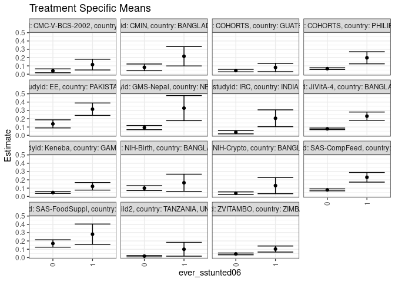

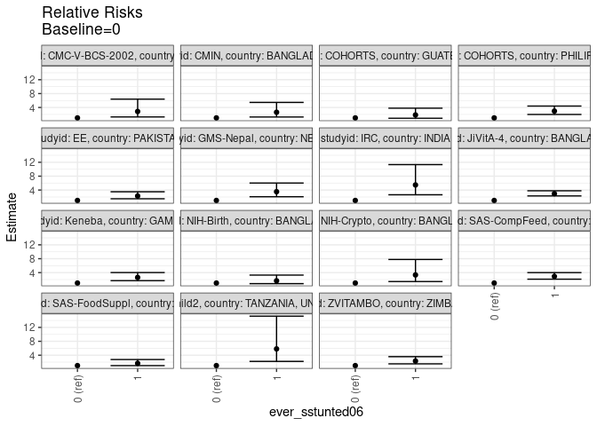

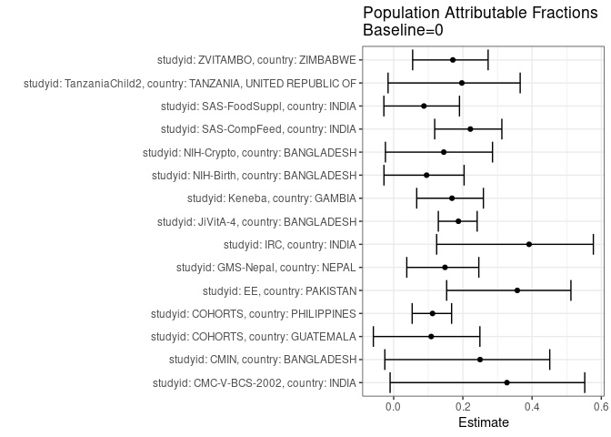

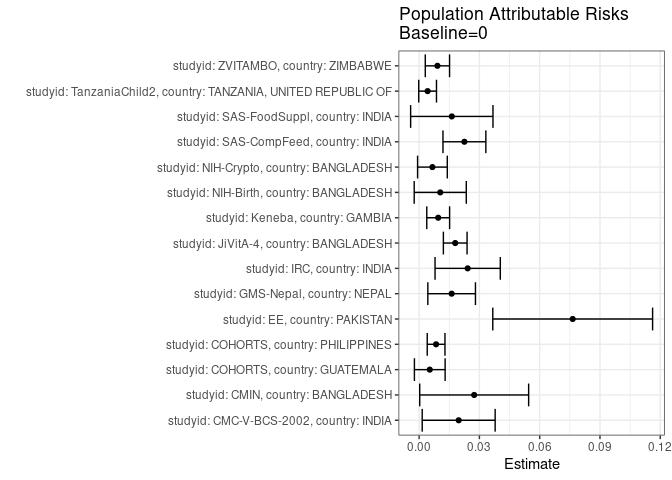

## Results Table

### Parameter: TSM

| studyid | country | intervention_level | baseline_level | estimate | ci_lower | ci_upper |
| --- | --- | --- | --- | --- | --- | --- |
| CMC-V-BCS-2002 | INDIA | 0 | NA | 0.0404277 | 0.0169938 | 0.0638617 |
| CMC-V-BCS-2002 | INDIA | 1 | NA | 0.1153734 | 0.0508654 | 0.1798814 |
| CMIN | BANGLADESH | 0 | NA | 0.0823068 | 0.0418943 | 0.1227193 |
| CMIN | BANGLADESH | 1 | NA | 0.2158337 | 0.0992839 | 0.3323836 |
| COHORTS | GUATEMALA | 0 | NA | 0.0435435 | 0.0280345 | 0.0590526 |
| COHORTS | GUATEMALA | 1 | NA | 0.0803571 | 0.0299792 | 0.1307351 |
| COHORTS | PHILIPPINES | 0 | NA | 0.0667421 | 0.0565207 | 0.0769635 |
| COHORTS | PHILIPPINES | 1 | NA | 0.1973801 | 0.1246938 | 0.2700663 |
| EE | PAKISTAN | 0 | NA | 0.1374530 | 0.0886482 | 0.1862579 |
| EE | PAKISTAN | 1 | NA | 0.3145210 | 0.2397141 | 0.3893278 |
| GMS-Nepal | NEPAL | 0 | NA | 0.0929045 | 0.0676520 | 0.1181570 |
| GMS-Nepal | NEPAL | 1 | NA | 0.3275186 | 0.1763834 | 0.4786537 |
| IRC | INDIA | 0 | NA | 0.0375682 | 0.0175057 | 0.0576306 |
| IRC | INDIA | 1 | NA | 0.2053669 | 0.1040483 | 0.3066855 |
| JiVitA-4 | BANGLADESH | 0 | NA | 0.0780490 | 0.0687708 | 0.0873272 |
| JiVitA-4 | BANGLADESH | 1 | NA | 0.2305475 | 0.1808817 | 0.2802133 |
| Keneba | GAMBIA | 0 | NA | 0.0468151 | 0.0363240 | 0.0573062 |
| Keneba | GAMBIA | 1 | NA | 0.1217319 | 0.0762063 | 0.1672575 |
| NIH-Birth | BANGLADESH | 0 | NA | 0.0998773 | 0.0707308 | 0.1290239 |
| NIH-Birth | BANGLADESH | 1 | NA | 0.1644610 | 0.0612171 | 0.2677050 |
| NIH-Crypto | BANGLADESH | 0 | NA | 0.0391156 | 0.0234332 | 0.0547981 |
| NIH-Crypto | BANGLADESH | 1 | NA | 0.1304348 | 0.0330346 | 0.2278350 |
| SAS-CompFeed | INDIA | 0 | NA | 0.0791301 | 0.0673603 | 0.0908999 |
| SAS-CompFeed | INDIA | 1 | NA | 0.2304133 | 0.1722489 | 0.2885777 |
| SAS-FoodSuppl | INDIA | 0 | NA | 0.1694952 | 0.1253227 | 0.2136677 |
| SAS-FoodSuppl | INDIA | 1 | NA | 0.2811861 | 0.1585843 | 0.4037879 |
| TanzaniaChild2 | TANZANIA, UNITED REPUBLIC OF | 0 | NA | 0.0172043 | 0.0088429 | 0.0255657 |
| TanzaniaChild2 | TANZANIA, UNITED REPUBLIC OF | 1 | NA | 0.1000000 | 0.0168033 | 0.1831967 |
| ZVITAMBO | ZIMBABWE | 0 | NA | 0.0441171 | 0.0334494 | 0.0547848 |
| ZVITAMBO | ZIMBABWE | 1 | NA | 0.1025147 | 0.0659470 | 0.1390823 |

### Parameter: E(Y)

| studyid | country | intervention_level | baseline_level | estimate | ci_lower | ci_upper |
| --- | --- | --- | --- | --- | --- | --- |
| CMC-V-BCS-2002 | INDIA | NA | NA | 0.0601093 | 0.0357249 | 0.0844936 |
| CMIN | BANGLADESH | NA | NA | 0.1097046 | 0.0698323 | 0.1495770 |
| COHORTS | GUATEMALA | NA | NA | 0.0488432 | 0.0336878 | 0.0639985 |
| COHORTS | PHILIPPINES | NA | NA | 0.0751910 | 0.0648251 | 0.0855569 |
| EE | PAKISTAN | NA | NA | 0.2138728 | 0.1706052 | 0.2571404 |
| GMS-Nepal | NEPAL | NA | NA | 0.1090909 | 0.0830130 | 0.1351688 |
| IRC | INDIA | NA | NA | 0.0617284 | 0.0382610 | 0.0851958 |
| JiVitA-4 | BANGLADESH | NA | NA | 0.0960141 | 0.0859500 | 0.1060782 |
| Keneba | GAMBIA | NA | NA | 0.0563063 | 0.0455826 | 0.0670300 |
| NIH-Birth | BANGLADESH | NA | NA | 0.1103896 | 0.0817833 | 0.1389959 |
| NIH-Crypto | BANGLADESH | NA | NA | 0.0457413 | 0.0294659 | 0.0620168 |
| SAS-CompFeed | INDIA | NA | NA | 0.1016680 | 0.0902317 | 0.1131043 |
| SAS-FoodSuppl | INDIA | NA | NA | 0.1857585 | 0.1432798 | 0.2282372 |
| TanzaniaChild2 | TANZANIA, UNITED REPUBLIC OF | NA | NA | 0.0214286 | 0.0123577 | 0.0304995 |
| ZVITAMBO | ZIMBABWE | NA | NA | 0.0532229 | 0.0425206 | 0.0639253 |

### Parameter: RR

| studyid | country | intervention_level | baseline_level | estimate | ci_lower | ci_upper |
| --- | --- | --- | --- | --- | --- | --- |
| CMC-V-BCS-2002 | INDIA | 0 | 0 | 1.000000 | 1.0000000 | 1.000000 |
| CMC-V-BCS-2002 | INDIA | 1 | 0 | 2.853818 | 1.2729531 | 6.397938 |
| CMIN | BANGLADESH | 0 | 0 | 1.000000 | 1.0000000 | 1.000000 |
| CMIN | BANGLADESH | 1 | 0 | 2.622307 | 1.2600412 | 5.457358 |
| COHORTS | GUATEMALA | 0 | 0 | 1.000000 | 1.0000000 | 1.000000 |
| COHORTS | GUATEMALA | 1 | 0 | 1.845443 | 0.8973427 | 3.795274 |
| COHORTS | PHILIPPINES | 0 | 0 | 1.000000 | 1.0000000 | 1.000000 |
| COHORTS | PHILIPPINES | 1 | 0 | 2.957355 | 1.9854205 | 4.405085 |
| EE | PAKISTAN | 0 | 0 | 1.000000 | 1.0000000 | 1.000000 |
| EE | PAKISTAN | 1 | 0 | 2.288207 | 1.4924440 | 3.508266 |
| GMS-Nepal | NEPAL | 0 | 0 | 1.000000 | 1.0000000 | 1.000000 |
| GMS-Nepal | NEPAL | 1 | 0 | 3.525324 | 2.0633594 | 6.023144 |
| IRC | INDIA | 0 | 0 | 1.000000 | 1.0000000 | 1.000000 |
| IRC | INDIA | 1 | 0 | 5.466514 | 2.6386814 | 11.324892 |
| JiVitA-4 | BANGLADESH | 0 | 0 | 1.000000 | 1.0000000 | 1.000000 |
| JiVitA-4 | BANGLADESH | 1 | 0 | 2.953881 | 2.3059466 | 3.783874 |
| Keneba | GAMBIA | 0 | 0 | 1.000000 | 1.0000000 | 1.000000 |
| Keneba | GAMBIA | 1 | 0 | 2.600269 | 1.6832667 | 4.016833 |
| NIH-Birth | BANGLADESH | 0 | 0 | 1.000000 | 1.0000000 | 1.000000 |
| NIH-Birth | BANGLADESH | 1 | 0 | 1.646630 | 0.8243267 | 3.289219 |
| NIH-Crypto | BANGLADESH | 0 | 0 | 1.000000 | 1.0000000 | 1.000000 |
| NIH-Crypto | BANGLADESH | 1 | 0 | 3.334594 | 1.4287411 | 7.782736 |
| SAS-CompFeed | INDIA | 0 | 0 | 1.000000 | 1.0000000 | 1.000000 |
| SAS-CompFeed | INDIA | 1 | 0 | 2.911829 | 2.1151851 | 4.008514 |
| SAS-FoodSuppl | INDIA | 0 | 0 | 1.000000 | 1.0000000 | 1.000000 |
| SAS-FoodSuppl | INDIA | 1 | 0 | 1.658962 | 1.0017186 | 2.747434 |
| TanzaniaChild2 | TANZANIA, UNITED REPUBLIC OF | 0 | 0 | 1.000000 | 1.0000000 | 1.000000 |
| TanzaniaChild2 | TANZANIA, UNITED REPUBLIC OF | 1 | 0 | 5.812500 | 2.2177450 | 15.234013 |
| ZVITAMBO | ZIMBABWE | 0 | 0 | 1.000000 | 1.0000000 | 1.000000 |
| ZVITAMBO | ZIMBABWE | 1 | 0 | 2.323695 | 1.5098696 | 3.576176 |

### Parameter: PAR

| studyid | country | intervention_level | baseline_level | estimate | ci_lower | ci_upper |
| --- | --- | --- | --- | --- | --- | --- |
| CMC-V-BCS-2002 | INDIA | 0 | NA | 0.0196815 | 0.0015309 | 0.0378322 |
| CMIN | BANGLADESH | 0 | NA | 0.0273978 | 0.0002932 | 0.0545025 |
| COHORTS | GUATEMALA | 0 | NA | 0.0052996 | -0.0023428 | 0.0129421 |
| COHORTS | PHILIPPINES | 0 | NA | 0.0084489 | 0.0040347 | 0.0128631 |
| EE | PAKISTAN | 0 | NA | 0.0764198 | 0.0366548 | 0.1161848 |
| GMS-Nepal | NEPAL | 0 | NA | 0.0161864 | 0.0043382 | 0.0280346 |
| IRC | INDIA | 0 | NA | 0.0241602 | 0.0079204 | 0.0404001 |
| JiVitA-4 | BANGLADESH | 0 | NA | 0.0179651 | 0.0120723 | 0.0238578 |
| Keneba | GAMBIA | 0 | NA | 0.0094912 | 0.0038081 | 0.0151743 |
| NIH-Birth | BANGLADESH | 0 | NA | 0.0105123 | -0.0024492 | 0.0234738 |
| NIH-Crypto | BANGLADESH | 0 | NA | 0.0066257 | -0.0007663 | 0.0140176 |
| SAS-CompFeed | INDIA | 0 | NA | 0.0225379 | 0.0118665 | 0.0332093 |
| SAS-FoodSuppl | INDIA | 0 | NA | 0.0162633 | -0.0042243 | 0.0367510 |
| TanzaniaChild2 | TANZANIA, UNITED REPUBLIC OF | 0 | NA | 0.0042243 | -0.0001918 | 0.0086404 |
| ZVITAMBO | ZIMBABWE | 0 | NA | 0.0091059 | 0.0030649 | 0.0151468 |

### Parameter: PAF

| studyid | country | intervention_level | baseline_level | estimate | ci_lower | ci_upper |
| --- | --- | --- | --- | --- | --- | --- |
| CMC-V-BCS-2002 | INDIA | 0 | NA | 0.3274293 | -0.0101810 | 0.5522076 |
| CMIN | BANGLADESH | 0 | NA | 0.2497419 | -0.0253869 | 0.4510489 |
| COHORTS | GUATEMALA | 0 | NA | 0.1085032 | -0.0585805 | 0.2492149 |
| COHORTS | PHILIPPINES | 0 | NA | 0.1123658 | 0.0535795 | 0.1675006 |
| EE | PAKISTAN | 0 | NA | 0.3573142 | 0.1531829 | 0.5122382 |
| GMS-Nepal | NEPAL | 0 | NA | 0.1483752 | 0.0379792 | 0.2461028 |
| IRC | INDIA | 0 | NA | 0.3913958 | 0.1242907 | 0.5770297 |
| JiVitA-4 | BANGLADESH | 0 | NA | 0.1871087 | 0.1291150 | 0.2412404 |
| Keneba | GAMBIA | 0 | NA | 0.1685636 | 0.0666710 | 0.2593325 |
| NIH-Birth | BANGLADESH | 0 | NA | 0.0952289 | -0.0278992 | 0.2036079 |
| NIH-Crypto | BANGLADESH | 0 | NA | 0.1448510 | -0.0237354 | 0.2856751 |
| SAS-CompFeed | INDIA | 0 | NA | 0.2216813 | 0.1186478 | 0.3126699 |
| SAS-FoodSuppl | INDIA | 0 | NA | 0.0875510 | -0.0281830 | 0.1902577 |
| TanzaniaChild2 | TANZANIA, UNITED REPUBLIC OF | 0 | NA | 0.1971326 | -0.0160720 | 0.3656001 |
| ZVITAMBO | ZIMBABWE | 0 | NA | 0.1710889 | 0.0549293 | 0.2729713 |